# Coding Session 1: Coding, Stats, and R Basics

# 3. Plots and Summary Statistics

## 3.1 Basic Plots

### Scatterplots

Scatterplots illustrate a relationship between two numeric variables.

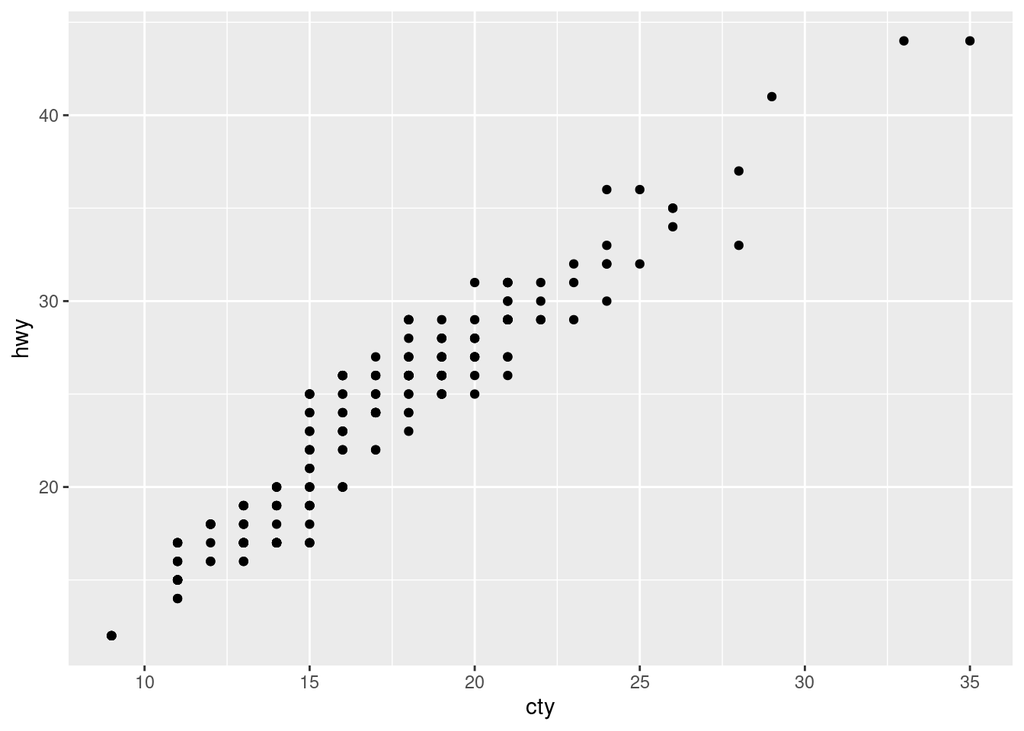

```r
# Most common syntax
ggplot(mpg) +
  geom_point(aes(x = cty, y = hwy))
```

```r
# Alternative syntax, can be too long (examples later)
ggplot(mpg) + geom_point(aes(x=cty, y = hwy))


# Syntax to illustrate each part
ggplot(mpg) +             # We want to plot "mpg"
  geom_point(             # Make a "point" plot (scatterplot)
    aes(x=cty, y = hwy)   # Aesthetically, cty is on x-axis, hwy is on y-axis
  )
```

`aes(...)` tells the plot what **aesthetics** you want it to have. Some examples of things to specify:

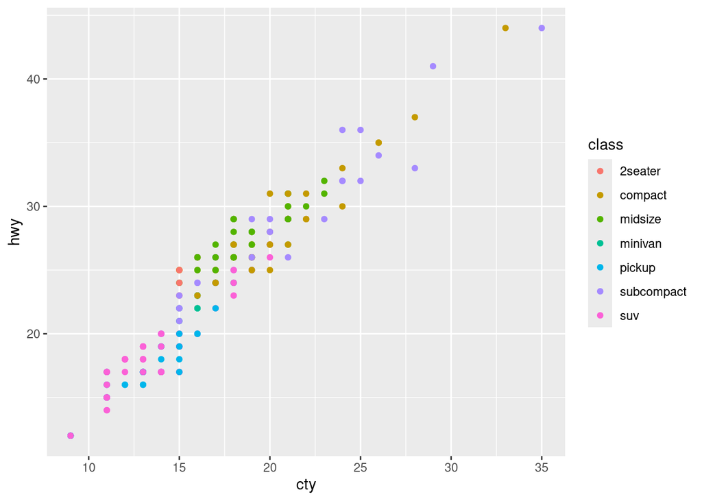

```r
# Colored by car type
ggplot(mpg) +
  geom_point(aes(x=cty, y = hwy, col = class))
```

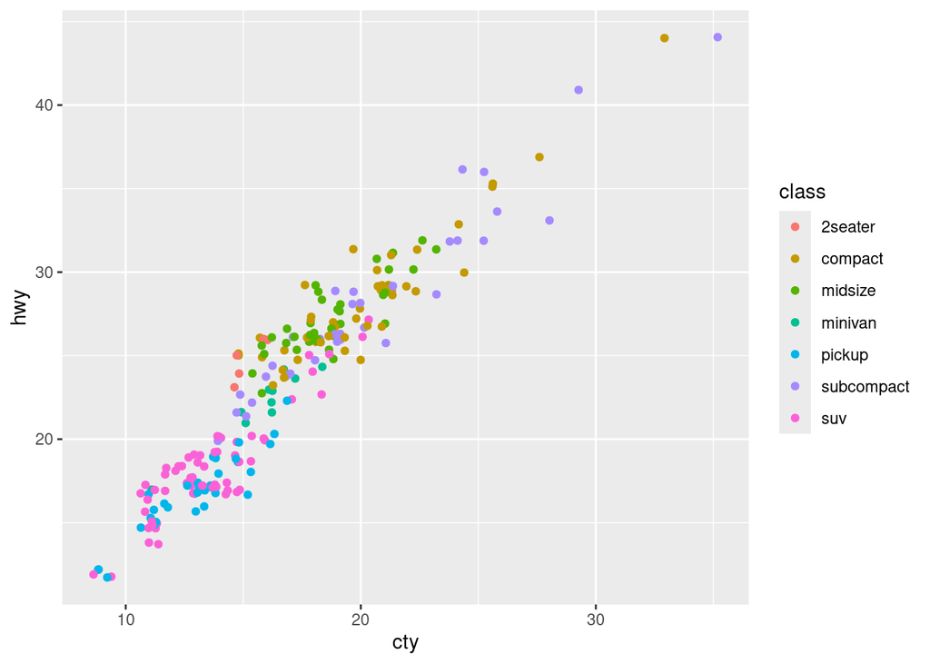

```r
# Adding jitter is useful when data might overlap.
ggplot(mpg) +
  geom_jitter(aes(x=cty, y = hwy, col = class))
```

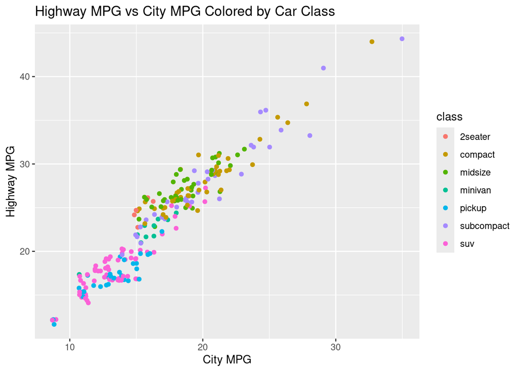

```r
# You can also add labels
ggplot(mpg) +
  geom_jitter(aes(x=cty, y = hwy, col = class)) +
  xlab("City MPG") +
  ylab("Highway MPG") +
  ggtitle("Highway MPG vs City MPG Colored by Car Class")
```

### CAUTION:

Use `geom_point` unless the data is overlapping (common when the numeric values are forced to be whole numbers). Only use `jitter` when needed *(otherwise the data is slightly misrepresented*).

### Challenge 4:

Answer a couple of questions based on the plot just created.

- What pattern do you notice between city and highway MPG? In particular, suppose that you know a car has a relatively high city MPG. What is likely about its highway MPG?
- What class of cars tend to have the lowest MPG (in general)?
- What class of cars tend to have the highest MPG (in general)?

## 3.2 Five Number Summaries

A five number summary (and mean) helps summarize numeric variables. It is best motivated by looking at the data a certain way. Let’s represent each mpg as a point on a plot.

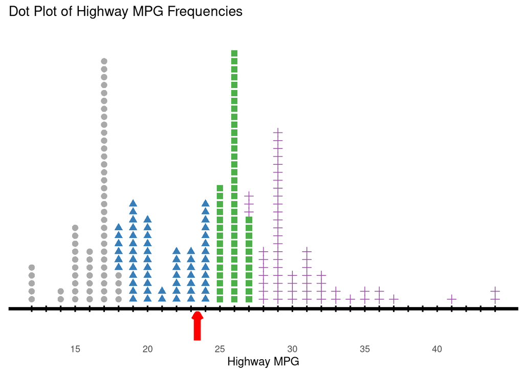

```r
summary(mpg$hwy)
```

```
##    Min. 1st Qu.  Median    Mean 3rd Qu.    Max.
##   12.00   18.00   24.00   23.44   27.00   44.00
```

- The **minimum** (`Min.`) highway mpg is 12. This represents the lowest data point in the dataset.
- The **maximum** (`Max.`) highway mpg is 44. This is the highest value observed in the dataset.
- The **mean** (`Mean`) highway mpg is 23.44. This is indicated by the arrow on the plot and can be thought of as the *center of balance*.
  - If the red arrow was moved to the left, then the right side would tip over. If it was moved to the right, then the left side would tip over.
- The **median** (`Median`, 24), **first quartile** (`1st Qu.`, 18) **third quartile** (`3rd Qu.`, 27) divide the data into **quarters** (or, fourths).
  - The circles are the smallest.
  - The triangles are the next smallest.
  - The squares are the next.
  - The plus’s are next *(so, they are the largest quarter of the data!)*

Another way to think about it:

- 25% of the data is at or below `1st Qu.`
- 50% of the data is at or below `Median` *(so, half of the data is at or below the median, and the other half is above.)*
- 75% of the data is at or below `3rd Qu.`

(*Note: the five number summary is `Min`, `1st Qu.`, `Median`, `3rd Qu.`, and `Max`. The mean is not considered as part of the “five number summary”.*)

### Boxplot

The five number summary is also expressed as a boxplot:

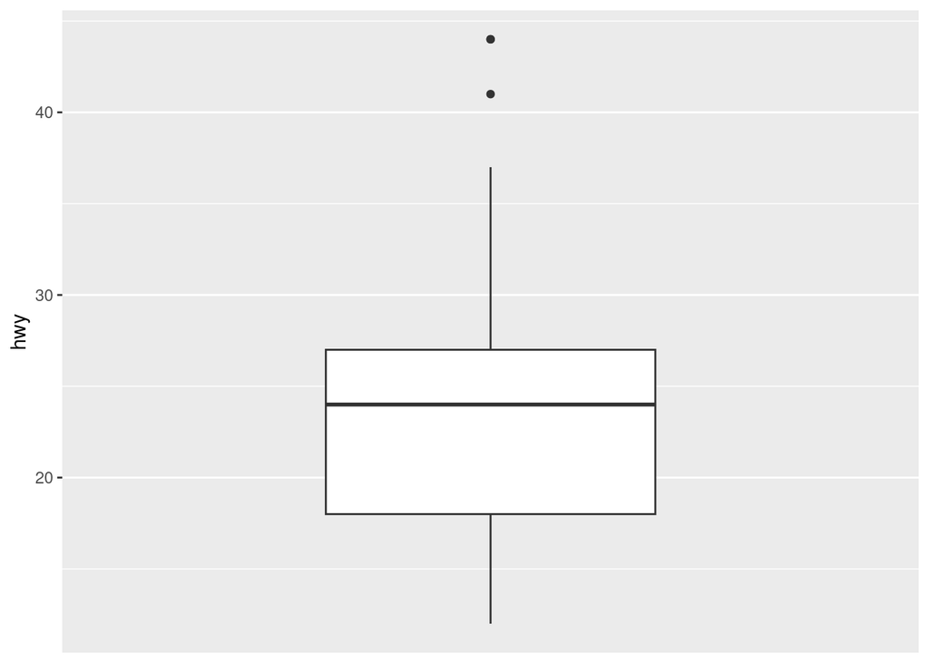

```r
# Single Boxplot
ggplot(mpg) +
  geom_boxplot(aes(y = hwy)) +   # boxplot with y axis as highway mpg
  scale_x_discrete()             # optional, but makes it look better
```

Look at the $y$-axis (`hwy`) and note that it matches the five number summary.

The dots represent **outliers** and are extreme values.

### Boxplot separated by categorical variable

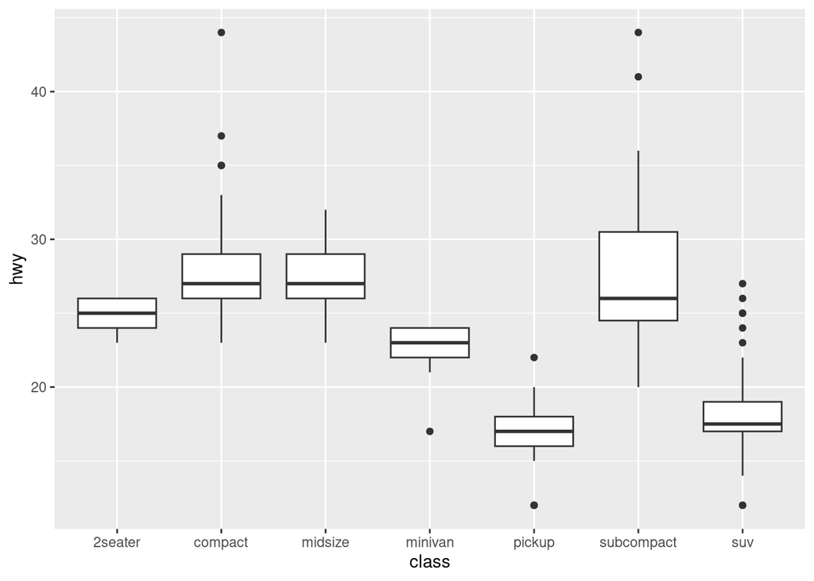

```r
# Separate hwy by vehicle class
ggplot(mpg) +
  geom_boxplot(aes(y = hwy, x = class))
```

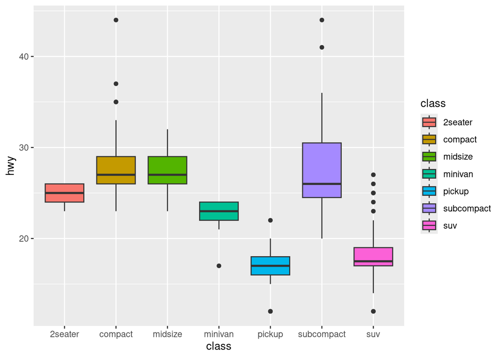

```r
# Add color (fill in the boxplot)
ggplot(mpg) +
  geom_boxplot(aes(y = hwy, x = class, fill = class))
```

## 3.3 Summarizing an entire dataset

`summary(mpg)` gives some summary statistics for each column of the data frame `mpg`.

- Numeric variables: five number summary and mean
- Categorical variables: reports the *count* or *frequency* of occurrences of each type

```r
# Basic summary of each column
summary(mpg)
```

```
##      manufacturer                 model         displ            year
##  dodge     :37    caravan 2wd        : 11   Min.   :1.600   Min.   :1999
##  toyota    :34    ram 1500 pickup 4wd: 10   1st Qu.:2.400   1st Qu.:1999
##  volkswagen:27    civic              :  9   Median :3.300   Median :2004
##  ford      :25    dakota pickup 4wd  :  9   Mean   :3.472   Mean   :2004
##  chevrolet :19    jetta              :  9   3rd Qu.:4.600   3rd Qu.:2008
##  audi      :18    mustang            :  9   Max.   :7.000   Max.   :2008
##  (Other)   :74    (Other)            :177
##       cyl               trans    drv          cty             hwy
##  Min.   :4.000   auto(l4)  :83   4:103   Min.   : 9.00   Min.   :12.00
##  1st Qu.:4.000   manual(m5):58   f:106   1st Qu.:14.00   1st Qu.:18.00
##  Median :6.000   auto(l5)  :39   r: 25   Median :17.00   Median :24.00
##  Mean   :5.889   manual(m6):19           Mean   :16.86   Mean   :23.44
##  3rd Qu.:8.000   auto(s6)  :16           3rd Qu.:19.00   3rd Qu.:27.00
##  Max.   :8.000   auto(l6)  : 6           Max.   :35.00   Max.   :44.00
##                  (Other)   :13
##  fl             class
##  c:  1   2seater   : 5
##  d:  5   compact   :47
##  e:  8   midsize   :41
##  p: 52   minivan   :11
##  r:168   pickup    :33
##          subcompact:35
##          suv       :62
```

For example, there are 62 SUV’s in the dataset and 11 minivans, and the average city mpg is 16.86.

```r
# Summary statistics for minivans.
#   Remember we defined "minivans" earlier?  Look in your environment!
summary(minivans)
```

```
##  manufacturer          model               displ            year
##  Length:11          Length:11          Min.   :2.400   Min.   :1999
##  Class :character   Class :character   1st Qu.:3.300   1st Qu.:1999
##  Mode  :character   Mode  :character   Median :3.300   Median :1999
##                                        Mean   :3.391   Mean   :2003
##                                        3rd Qu.:3.800   3rd Qu.:2008
##                                        Max.   :4.000   Max.   :2008
##       cyl           trans               drv                 cty
##  Min.   :4.000   Length:11          Length:11          Min.   :11.00
##  1st Qu.:6.000   Class :character   Class :character   1st Qu.:15.50
##  Median :6.000   Mode  :character   Mode  :character   Median :16.00
##  Mean   :5.818                                         Mean   :15.82
##  3rd Qu.:6.000                                         3rd Qu.:17.00
##  Max.   :6.000                                         Max.   :18.00
##       hwy             fl               class
##  Min.   :17.00   Length:11          Length:11
##  1st Qu.:22.00   Class :character   Class :character
##  Median :23.00   Mode  :character   Mode  :character
##  Mean   :22.36
##  3rd Qu.:24.00
##  Max.   :24.00
```

### Other Summary Statistics

```r
# Table of counts separated by two categorical variables
table(mpg$class, mpg$drv)
```

```
##
##               4  f  r
##   2seater     0  0  5
##   compact    12 35  0
##   midsize     3 38  0
##   minivan     0 11  0
##   pickup     33  0  0
##   subcompact  4 22  9
##   suv        51  0 11
```

For example, there are 12 compacts with 4 wheel drive, and all minivans (11) have front wheel drive.

## 3.4 Other Plotting Tools

### Histograms

**Histograms** are useful for numeric variables that can take **decimal values** *(decimal valued variables are called “continuous”. Whole number valued are called “discrete”)*.

They “bin” the data into ranges.

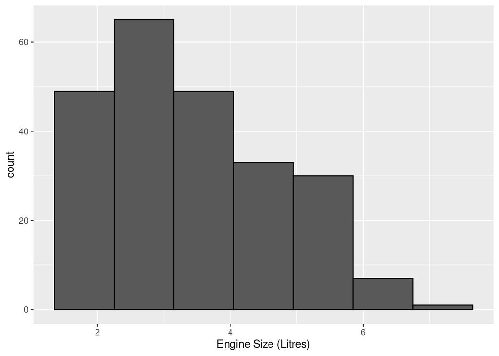

```r
# Using 7 bins
ggplot(mpg) +
  geom_histogram(aes(x = displ), bins = 7, col = "black") +
  xlab("Engine Size (Litres)")
```

So there are roughly…

- 49 engines with a size between (approximately) 1.4 to 2.3, (first “bin” or rectangle)
- 65 engines with a size between (approximately) 2.3 to 3.2, (first “bin” or rectangle)
- 49 engines with a size between (approximately) 3.2 to 4.1, (first “bin” or rectangle)

and so forth.

Histograms are helpful to describe the **general shape** (a **visual summary**) of a numeric variable. So we can see that the number of engines with large sizes are very small, and that number decreases very quickly. The majority of engines are around the 1 to 4 litre range.

You can change the number of bins that get used, but it will change the way the results are displayed.

- Use too few bins, and the data gets “over-summarized”.
- Use too many bins, and the results are too fine. It is hard to come up with general conclusions of the data.

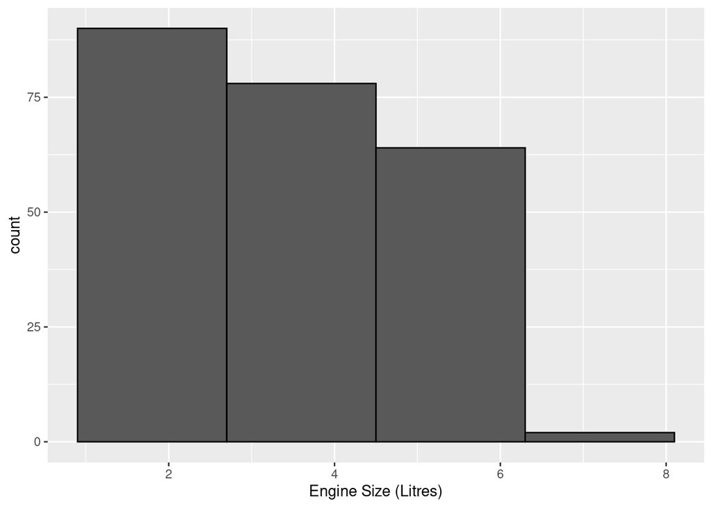

```r
# 4 bins, over-summarized
ggplot(mpg) +
  geom_histogram(aes(x = displ), bins = 4, col = "black") +
  xlab("Engine Size (Litres)")
```

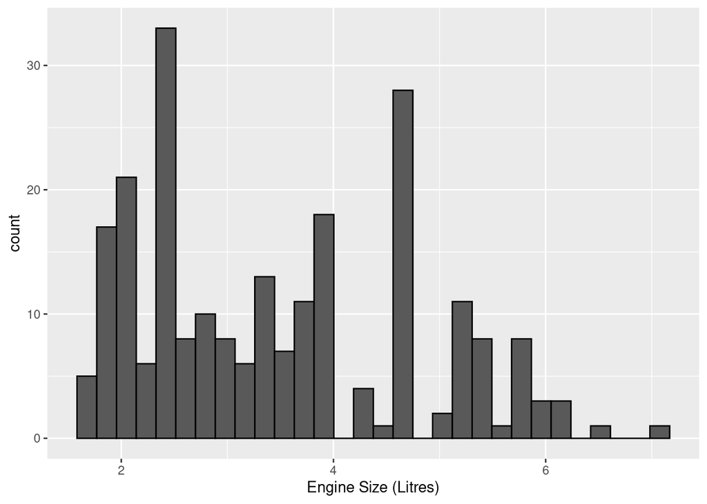

```r
# 30 bins, does not give good summary
ggplot(mpg) +
  geom_histogram(aes(x = displ), bins = 30, col = "black") +
  xlab("Engine Size (Litres)")
```

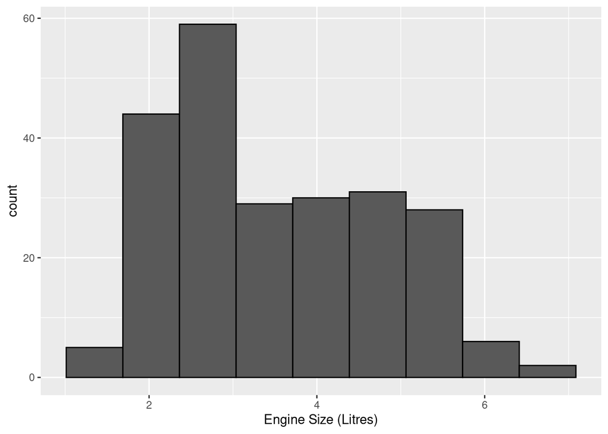

```r
# 9 bins, does a pretty good job
ggplot(mpg) +
  geom_histogram(aes(x = displ), bins = 9, col = "black") +
  xlab("Engine Size (Litres)")
```

Here we can see the data **“tails off”** to the right, and the majority is around 2 and 3 size engines.